# Course Project 1

Jingwei Li

07032017

## Loading and preprocessing the data.

Show any code that is needed to.

1.Load the data (i.e. read.csv())  
2.Process/transform the data (if necessary) into a format suitable for your analysis

```r
activity_data <- read.csv("activity.csv", stringsAsFactors = F)
activity_data$date <- as.Date(activity_data$date)
```

## What is mean total number of steps taken per day?

For this part of the assignment, you can ignore the missing values in the dataset.

1.Calculate the total number of steps taken per day

```r
steps_day <- tapply(X = activity_data$steps, INDEX = activity_data$date, FUN = sum, na.rm = T)
```

2.If you do not understand the difference between a histogram and a barplot, research the difference between them. Make a histogram of the total number of steps taken each day

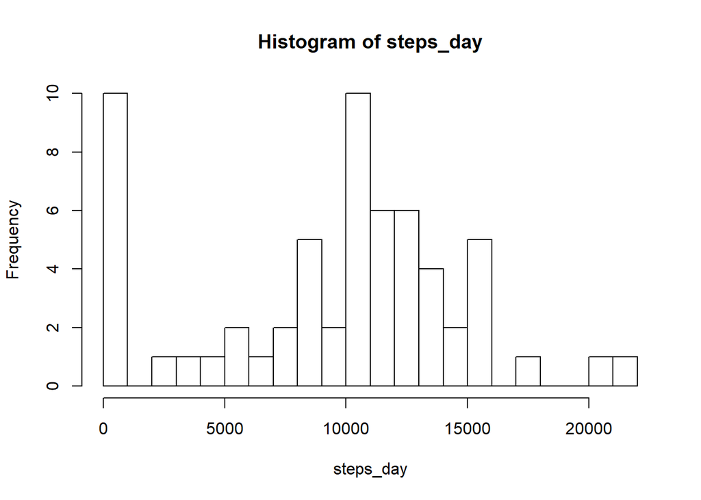

```r
hist(steps_day, breaks = 20)
```

3.Calculate and report the mean and median of the total number of steps taken per day

```r
steps_day_mean <- mean(steps_day)
steps_day_median <- median(steps_day)
```

Mean is 9354.2295082 and median is 10395.

## What is the average daily activity pattern?

1.Make a time series plot (i.e. type = “l”) of the 5-minute interval (x-axis) and the average number of steps taken, averaged across all days (y-axis)

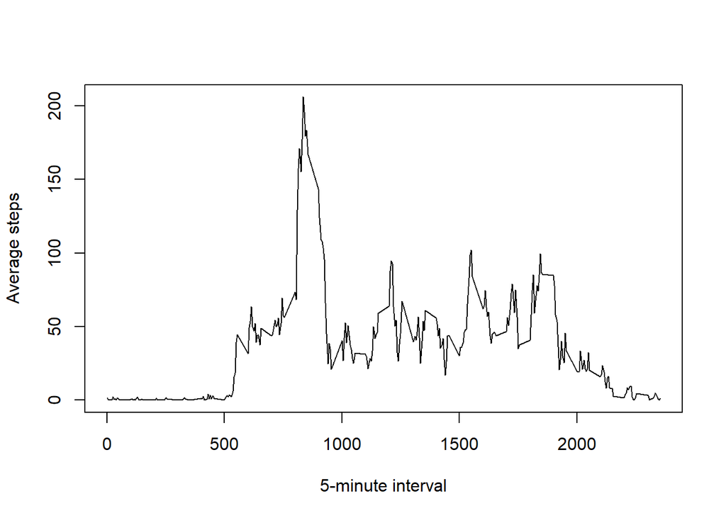

```r
steps_interval_mean <- tapply(X = activity_data$steps, INDEX = activity_data$interval, FUN = mean, na.rm = T)
plot(names(steps_interval_mean), steps_interval_mean, type = "l", xlab = "5-minute interval", ylab = "Average steps")
```

2.Which 5-minute interval, on average across all the days in the dataset, contains the maximum number of steps?

```r
max_step <- max(steps_interval_mean)
max_int <- names(steps_interval_mean)[which(steps_interval_mean == max_step)]
```

Interval 835 has the maximum number of steps across all the days in dataset.

## Imputing missing values

Note that there are a number of days/intervals where there are missing values (coded as NA). The presence of missing days may introduce bias into some calculations or summaries of the data.

1.Calculate and report the total number of missing values in the dataset (i.e. the total number of rows with NAs)

```r
num_na <- sum(is.na(activity_data$steps))
```

The total number of missing values is 2304.

2.Devise a strategy for filling in all of the missing values in the dataset. The strategy does not need to be sophisticated. For example, you could use the mean/median for that day, or the mean for that 5-minute interval, etc.

I decide to use the mean for that 5-minute interval to replace the missing values.

3.Create a new dataset that is equal to the original dataset but with the missing data filled in.

```r
imputed_data <- activity_data
imputed_data$steps[which(is.na(activity_data$steps))] <- as.numeric(steps_interval_mean[as.character(activity_data$interval[which(is.na(activity_data$steps))])])
```

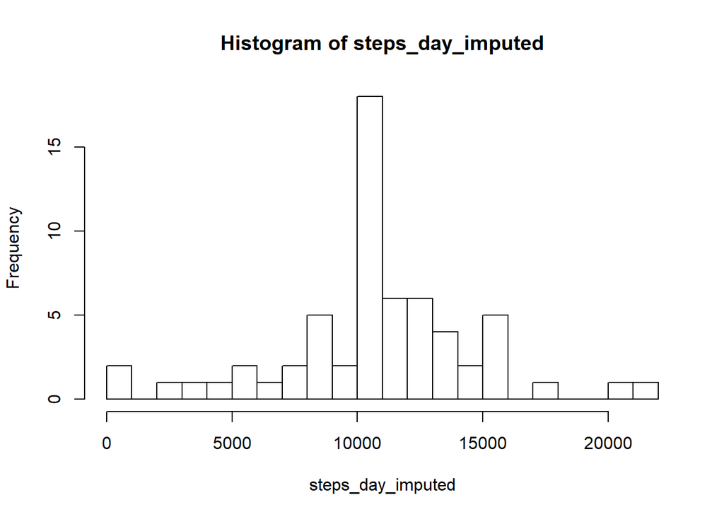

```r
steps_day_imputed <- tapply(X = imputed_data$steps, INDEX = imputed_data$date, FUN = sum, na.rm = T)
hist(steps_day_imputed, breaks = 20)
```

```r
steps_day_imputed_mean <- mean(steps_day_imputed)
steps_day_imputed_median <- median(steps_day_imputed)
```

## Are there differences in activity patterns between weekdays and weekends?

For this part the weekdays() function may be of some help here. Use the dataset with the filled-in missing values for this part.

1.Create a new factor variable in the dataset with two levels weekday and weekend indicating whether a given date is a weekday or weekend day.

```r
imputed_data$type <- ifelse(weekdays(imputed_data[,2]) == "Saturday" | weekdays(imputed_data[,2]) == "Sunday", 'weekend', 'weekday')
```

2.Make a panel plot containing a time series plot (i.e. type = “l”) of the 5-minute interval (x-axis) and the average number of steps taken, averaged across all weekday days or weekend days (y-axis). See the README file in the GitHub repository to see an example of what this plot should look like using simulated data.

```r
imputed_data$type <- as.factor(imputed_data$type)
str(imputed_data)
```

```
## 'data.frame':    17568 obs. of  4 variables:
##  $ steps   : num  1.717 0.3396 0.1321 0.1509 0.0755 ...
##  $ date    : Date, format: "2012-10-01" "2012-10-01" ...
##  $ interval: int  0 5 10 15 20 25 30 35 40 45 ...
##  $ type    : Factor w/ 2 levels "weekday","weekend": 1 1 1 1 1 1 1 1 1 1 ...
```

```r
aggregate_data <- aggregate(x = imputed_data$steps,
                            list(imputed_data$interval, imputed_data$type),
                            FUN = "mean")
names(aggregate_data) <- c("interval","type", "steps")
str(aggregate_data)
```

```
## 'data.frame':    576 obs. of  3 variables:
##  $ interval: int  0 5 10 15 20 25 30 35 40 45 ...
##  $ type    : Factor w/ 2 levels "weekday","weekend": 1 1 1 1 1 1 1 1 1 1 ...
##  $ steps   : num  2.251 0.445 0.173 0.198 0.099 ...
```

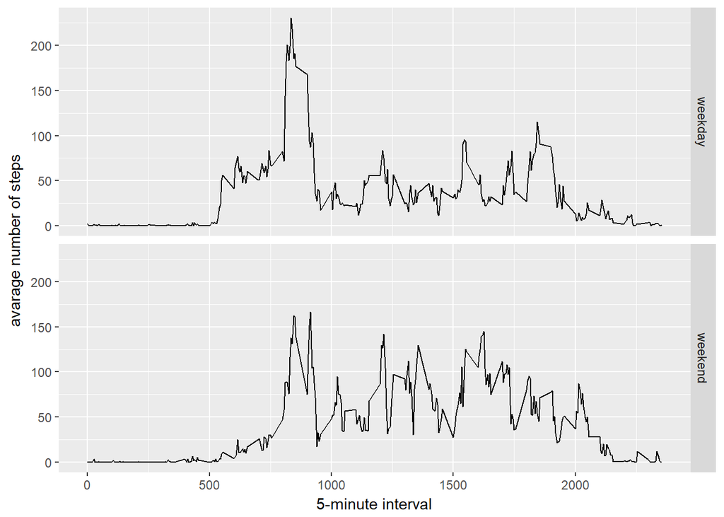

```r
ggplot(aggregate_data, aes(interval, steps)) +
    geom_line() +
    facet_grid(type ~ .) +
    xlab("5-minute interval") +
    ylab("avarage number of steps")
```